# Problem Statement:-

Examining real estate valuation helps understand where people tend to live in a city. The higher the price, the greater the demand to live in the property. Predicting real estate valuation can help urban design and urban policies, as it could help identify what factors have the most impact on property prices. Our aim is to predict real estate value, based on several features. Our objective is to:

1. Understand the data available
2. Test best regression models
3. Assess the best model and improve them
4. Present the results and address the results

Attribute Information: The inputs are as follows X1=the transaction date (for example, 2013.250=2013 March, 2013.500=2013 June, etc.) X2=the house age (unit: year) X3=the distance to the nearest MRT station (unit: meter) X4=the number of convenience stores in the living circle on foot (integer) X5=the geographic coordinate, latitude. (unit: degree) X6=the geographic coordinate, longitude. (unit: degree) The output is as follow Y= house price of unit area

# Import all required libraries

```python
import numpy as np
import matplotlib.pyplot as plt
import seaborn as sns
import pandas as pd
import statsmodels.api as sm
```

# Import real_estate dataset

```python
data= pd.read_csv('real_estate.csv')
```

```python
data
```

|  | No | X1 transaction date | X2 house age | X3 distance to the nearest MRT station | X4 number of convenience stores | X5 latitude | X6 longitude | Y house price of unit area |
| --- | --- | --- | --- | --- | --- | --- | --- | --- |
| 0 | 1 | 2012.917 | 32.0 | 84.87882 | 10 | 24.98298 | 121.54024 | 37.9 |
| 1 | 2 | 2012.917 | 19.5 | 306.59470 | 9 | 24.98034 | 121.53951 | 42.2 |
| 2 | 3 | 2013.583 | 13.3 | 561.98450 | 5 | 24.98746 | 121.54391 | 47.3 |
| 3 | 4 | 2013.500 | 13.3 | 561.98450 | 5 | 24.98746 | 121.54391 | 54.8 |
| 4 | 5 | 2012.833 | 5.0 | 390.56840 | 5 | 24.97937 | 121.54245 | 43.1 |
| ... | ... | ... | ... | ... | ... | ... | ... | ... |
| 409 | 410 | 2013.000 | 13.7 | 4082.01500 | 0 | 24.94155 | 121.50381 | 15.4 |
| 410 | 411 | 2012.667 | 5.6 | 90.45606 | 9 | 24.97433 | 121.54310 | 50.0 |
| 411 | 412 | 2013.250 | 18.8 | 390.96960 | 7 | 24.97923 | 121.53986 | 40.6 |
| 412 | 413 | 2013.000 | 8.1 | 104.81010 | 5 | 24.96674 | 121.54067 | 52.5 |
| 413 | 414 | 2013.500 | 6.5 | 90.45606 | 9 | 24.97433 | 121.54310 | 63.9 |

414 rows × 8 columns

# data preprocessing

```python
data=data.rename({"X1 transaction date":"transaction date",
                 "X2 house age":"house age",
                 "X3 distance to the nearest MRT station":"distance to the nearest MRT station",
                 "X4 number of convenience stores":"number of convenience stores",
                 "X5 latitude":"latitude",
                 "X6 longitude":"longitude",
                 "Y house price of unit area":"house price"}, axis='columns')
```

```python
data
```

|  | No | transaction date | house age | distance to the nearest MRT station | number of convenience stores | latitude | longitude | house price |
| --- | --- | --- | --- | --- | --- | --- | --- | --- |
| 0 | 1 | 2012.917 | 32.0 | 84.87882 | 10 | 24.98298 | 121.54024 | 37.9 |
| 1 | 2 | 2012.917 | 19.5 | 306.59470 | 9 | 24.98034 | 121.53951 | 42.2 |
| 2 | 3 | 2013.583 | 13.3 | 561.98450 | 5 | 24.98746 | 121.54391 | 47.3 |
| 3 | 4 | 2013.500 | 13.3 | 561.98450 | 5 | 24.98746 | 121.54391 | 54.8 |
| 4 | 5 | 2012.833 | 5.0 | 390.56840 | 5 | 24.97937 | 121.54245 | 43.1 |
| ... | ... | ... | ... | ... | ... | ... | ... | ... |
| 409 | 410 | 2013.000 | 13.7 | 4082.01500 | 0 | 24.94155 | 121.50381 | 15.4 |
| 410 | 411 | 2012.667 | 5.6 | 90.45606 | 9 | 24.97433 | 121.54310 | 50.0 |
| 411 | 412 | 2013.250 | 18.8 | 390.96960 | 7 | 24.97923 | 121.53986 | 40.6 |
| 412 | 413 | 2013.000 | 8.1 | 104.81010 | 5 | 24.96674 | 121.54067 | 52.5 |
| 413 | 414 | 2013.500 | 6.5 | 90.45606 | 9 | 24.97433 | 121.54310 | 63.9 |

414 rows × 8 columns

```python
data.info()
```

```
<class 'pandas.core.frame.DataFrame'>
RangeIndex: 414 entries, 0 to 413
Data columns (total 8 columns):
 #   Column                               Non-Null Count  Dtype
---  ------                               --------------  -----
 0   No                                   414 non-null    int64
 1   transaction date                     414 non-null    float64
 2   house age                            414 non-null    float64
 3   distance to the nearest MRT station  414 non-null    float64
 4   number of convenience stores         414 non-null    int64
 5   latitude                             414 non-null    float64
 6   longitude                            414 non-null    float64
 7   house price                          414 non-null    float64
dtypes: float64(6), int64(2)
memory usage: 26.0 KB
```

```python
data.describe()
```

|  | No | transaction date | house age | distance to the nearest MRT station | number of convenience stores | latitude | longitude | house price |
| --- | --- | --- | --- | --- | --- | --- | --- | --- |
| count | 414.000000 | 414.000000 | 414.000000 | 414.000000 | 414.000000 | 414.000000 | 414.000000 | 414.000000 |
| mean | 207.500000 | 2013.148971 | 17.712560 | 1083.885689 | 4.094203 | 24.969030 | 121.533361 | 37.980193 |
| std | 119.655756 | 0.281967 | 11.392485 | 1262.109595 | 2.945562 | 0.012410 | 0.015347 | 13.606488 |
| min | 1.000000 | 2012.667000 | 0.000000 | 23.382840 | 0.000000 | 24.932070 | 121.473530 | 7.600000 |
| 25% | 104.250000 | 2012.917000 | 9.025000 | 289.324800 | 1.000000 | 24.963000 | 121.528085 | 27.700000 |
| 50% | 207.500000 | 2013.167000 | 16.100000 | 492.231300 | 4.000000 | 24.971100 | 121.538630 | 38.450000 |
| 75% | 310.750000 | 2013.417000 | 28.150000 | 1454.279000 | 6.000000 | 24.977455 | 121.543305 | 46.600000 |
| max | 414.000000 | 2013.583000 | 43.800000 | 6488.021000 | 10.000000 | 25.014590 | 121.566270 | 117.500000 |

# feature selection

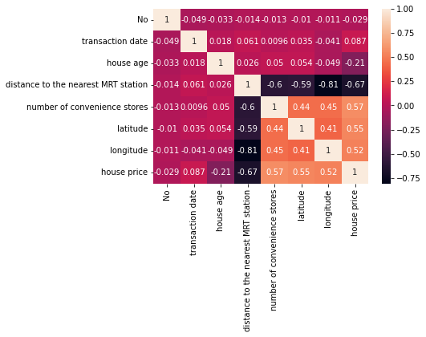

```python
corr = data.corr()
sns.heatmap(corr,annot=True,
            xticklabels=corr.columns.values,
            yticklabels=corr.columns.values)
```

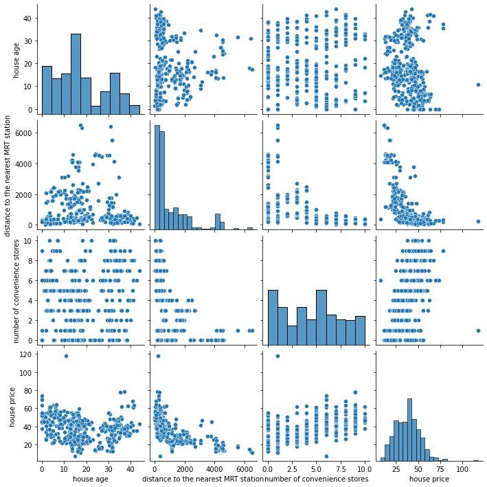

```python
sns.pairplot(data[['house age','distance to the nearest MRT station','number of convenience stores','house price']])
```

```python
a=np.log10(data['distance to the nearest MRT station'])
```

```python
a
```

```
0      1.928799
1      2.486565
2      2.749724
3      2.749724
4      2.591697
         ...
409    3.610875
410    1.956438
411    2.592143
412    2.020403
413    1.956438
Name: distance to the nearest MRT station, Length: 414, dtype: float64
```

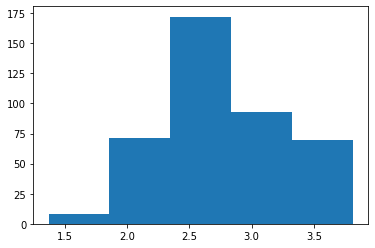

```python
plt.hist(a, bins=5)
plt.show()
```

```python
data['distance to the nearest MRT station'] = a
```

```python
data
```

|  | No | transaction date | house age | distance to the nearest MRT station | number of convenience stores | latitude | longitude | house price |
| --- | --- | --- | --- | --- | --- | --- | --- | --- |
| 0 | 1 | 2012.917 | 32.0 | 1.928799 | 10 | 24.98298 | 121.54024 | 37.9 |
| 1 | 2 | 2012.917 | 19.5 | 2.486565 | 9 | 24.98034 | 121.53951 | 42.2 |
| 2 | 3 | 2013.583 | 13.3 | 2.749724 | 5 | 24.98746 | 121.54391 | 47.3 |
| 3 | 4 | 2013.500 | 13.3 | 2.749724 | 5 | 24.98746 | 121.54391 | 54.8 |
| 4 | 5 | 2012.833 | 5.0 | 2.591697 | 5 | 24.97937 | 121.54245 | 43.1 |
| ... | ... | ... | ... | ... | ... | ... | ... | ... |
| 409 | 410 | 2013.000 | 13.7 | 3.610875 | 0 | 24.94155 | 121.50381 | 15.4 |
| 410 | 411 | 2012.667 | 5.6 | 1.956438 | 9 | 24.97433 | 121.54310 | 50.0 |
| 411 | 412 | 2013.250 | 18.8 | 2.592143 | 7 | 24.97923 | 121.53986 | 40.6 |
| 412 | 413 | 2013.000 | 8.1 | 2.020403 | 5 | 24.96674 | 121.54067 | 52.5 |
| 413 | 414 | 2013.500 | 6.5 | 1.956438 | 9 | 24.97433 | 121.54310 | 63.9 |

414 rows × 8 columns

```python
corr = data.corr()
corr
```

|  | No | transaction date | house age | distance to the nearest MRT station | number of convenience stores | latitude | longitude | house price |
| --- | --- | --- | --- | --- | --- | --- | --- | --- |
| No | 1.000000 | -0.048658 | -0.032808 | -0.024862 | -0.012699 | -0.010110 | -0.011059 | -0.028587 |
| transaction date | -0.048658 | 1.000000 | 0.017549 | 0.097745 | 0.009635 | 0.035058 | -0.041082 | 0.087491 |
| house age | -0.032808 | 0.017549 | 1.000000 | 0.067322 | 0.049593 | 0.054420 | -0.048520 | -0.210567 |
| distance to the nearest MRT station | -0.024862 | 0.097745 | 0.067322 | 1.000000 | -0.685516 | -0.456663 | -0.649503 | -0.734339 |
| number of convenience stores | -0.012699 | 0.009635 | 0.049593 | -0.685516 | 1.000000 | 0.444143 | 0.449099 | 0.571005 |
| latitude | -0.010110 | 0.035058 | 0.054420 | -0.456663 | 0.444143 | 1.000000 | 0.412924 | 0.546307 |
| longitude | -0.011059 | -0.041082 | -0.048520 | -0.649503 | 0.449099 | 0.412924 | 1.000000 | 0.523287 |
| house price | -0.028587 | 0.087491 | -0.210567 | -0.734339 | 0.571005 | 0.546307 | 0.523287 | 1.000000 |

```python
features= data.drop(['No','house price','transaction date','latitude','longitude'],axis=1)
features
```

|  | house age | distance to the nearest MRT station | number of convenience stores |
| --- | --- | --- | --- |
| 0 | 32.0 | 1.928799 | 10 |
| 1 | 19.5 | 2.486565 | 9 |
| 2 | 13.3 | 2.749724 | 5 |
| 3 | 13.3 | 2.749724 | 5 |
| 4 | 5.0 | 2.591697 | 5 |
| ... | ... | ... | ... |
| 409 | 13.7 | 3.610875 | 0 |
| 410 | 5.6 | 1.956438 | 9 |
| 411 | 18.8 | 2.592143 | 7 |
| 412 | 8.1 | 2.020403 | 5 |
| 413 | 6.5 | 1.956438 | 9 |

414 rows × 3 columns

```python
target = data['house price']
```

```python
target
```

```
0      37.9
1      42.2
2      47.3
3      54.8
4      43.1
       ...
409    15.4
410    50.0
411    40.6
412    52.5
413    63.9
Name: house price, Length: 414, dtype: float64
```

# Split file

```python
from sklearn.model_selection import train_test_split
featurestrain, featurestest, targettrain, targettest = train_test_split(features,target,test_size=0.333,
                                                random_state=1)
```

```python
featurestrain[0:20]
```

|  | house age | distance to the nearest MRT station | number of convenience stores |
| --- | --- | --- | --- |
| 327 | 3.5 | 2.879290 | 3 |
| 413 | 6.5 | 1.956438 | 9 |
| 283 | 33.5 | 3.296374 | 2 |
| 331 | 25.6 | 3.655109 | 0 |
| 334 | 30.0 | 3.005756 | 5 |
| 251 | 31.7 | 3.064254 | 0 |
| 371 | 4.1 | 2.495400 | 5 |
| 355 | 3.8 | 2.584176 | 5 |
| 88 | 8.9 | 3.148118 | 0 |
| 131 | 4.0 | 3.331908 | 3 |
| 124 | 9.9 | 2.445873 | 7 |
| 258 | 0.0 | 2.466864 | 6 |
| 14 | 13.2 | 3.066266 | 4 |
| 174 | 4.3 | 2.635522 | 7 |
| 123 | 0.0 | 2.268179 | 0 |
| 138 | 10.0 | 2.974266 | 0 |
| 111 | 33.3 | 2.293622 | 7 |
| 51 | 31.3 | 3.245119 | 1 |
| 112 | 9.9 | 3.322721 | 3 |
| 9 | 17.9 | 3.251195 | 3 |

# To make scaler featurestrain and featurestest

```python
from sklearn.preprocessing import MinMaxScaler
scaler= MinMaxScaler()
featurestrain = scaler.fit_transform(featurestrain)
featurestest = scaler.fit_transform(featurestest)
```

# Model selection

```python
model_ = sm.OLS(targettrain,featurestrain).fit()
model_
```

```
<statsmodels.regression.linear_model.RegressionResultsWrapper at 0x2586476f820>
```

```python
model_.summary()
```

OLS Regression Results

| Dep. Variable: | house price | R-squared (uncentered): | 0.893 |
| --- | --- | --- | --- |
| Model: | OLS | Adj. R-squared (uncentered): | 0.892 |
| Method: | Least Squares | F-statistic: | 759.0 |
| Date: | Sat, 08 Oct 2022 | Prob (F-statistic): | 4.35e-132 |
| Time: | 01:53:33 | Log-Likelihood: | -1100.9 |
| No. Observations: | 276 | AIC: | 2208. |
| Df Residuals: | 273 | BIC: | 2219. |
| Df Model: | 3 |  |  |
| Covariance Type: | nonrobust |  |  |

|  | coef | std err | t | P>\|t\| | [0.025 | 0.975] |
| --- | --- | --- | --- | --- | --- | --- |
| x1 | -0.3031 | 2.882 | -0.105 | 0.916 | -5.977 | 5.371 |
| x2 | 27.5524 | 2.273 | 12.123 | 0.000 | 23.078 | 32.027 |
| x3 | 48.6900 | 2.174 | 22.393 | 0.000 | 44.409 | 52.971 |

| Omnibus: | 9.459 | Durbin-Watson: | 1.862 |
| --- | --- | --- | --- |
| Prob(Omnibus): | 0.009 | Jarque-Bera (JB): | 9.771 |
| Skew: | 0.461 | Prob(JB): | 0.00756 |
| Kurtosis: | 3.009 | Cond. No. | 3.68 |

Notes:  
[1] R² is computed without centering (uncentered) since the model does not contain a constant.  
[2] Standard Errors assume that the covariance matrix of the errors is correctly specified.

```python
model_.predict(featurestest)
```

```
388    41.741742
102    42.497277
187    26.710116
162    26.839643
90     23.467525
         ...
314    45.971818
125    42.497277
59     38.900428
120    40.219274
12     40.254457
Length: 138, dtype: float64
```